# assignment

```r
stocks <- read.csv("stocks.csv")
nrow(stocks)
```

```
## [1] 147
```

```r
head(stocks)
```

```
##                                Name Symbol Market
## 1                   CDW Corporation    CDW    NDX
## 2                    VeriSign, Inc.   VRSN    NDX
## 3            Verisk Analytics, Inc.   VRSK    NDX
## 4 Microchip Technology Incorporated   MCHP    NDX
## 5                      JD.com, Inc.     JD    NDX
## 6                       Intuit Inc.   INTU    NDX
##                            Sector          Industry Market.cap..intra.day.
## 1 Information Technology Services        Technology                  16.46
## 2       Software鈥擨nfrastructure        Technology                  23.94
## 3             Consulting Services       Industrials                  30.37
## 4                  Semiconductors        Technology                  25.81
## 5                 Internet Retail Consumer Cyclical                  95.77
## 6          Software鈥擜pplication        Technology                  79.26
##   Enterprise.value Trailing.P.E Forward.P.E PEG.ratio..5.yr.expected.
```

[output cut: 27 more lines]

```r
stocks <- na.omit(stocks)%>%
  rename(intra_day=Market.cap..intra.day.)%>%
  rename(ent_value=Enterprise.value)%>%
  rename(trail_pe=Trailing.P.E)%>%
  rename(for_pe=Forward.P.E)%>%
  rename(peg=PEG.ratio..5.yr.expected.)%>%
  rename(ttm=Price.sales..ttm.)%>%
  rename(mrq=Price.book..mrq.)%>%
  rename(rev=Enterprise.value.revenue)%>%
  rename(ebitda=Enterprise.value.EBITDA)
#stocks <- na.omit(stocks)
#nrow(stocks)
```

147 variables with 102 having the missing value

```r
summary(stocks)
```

```
##      Name              Symbol             Market             Sector
##  Length:45          Length:45          Length:45          Length:45
##  Class :character   Class :character   Class :character   Class :character
##  Mode  :character   Mode  :character   Mode  :character   Mode  :character
##
##
##
##    Industry           intra_day           ent_value            trail_pe
##  Length:45          Min.   :      6.4   Min.   :      7.8   Min.   :  7.54
##  Class :character   1st Qu.:     36.3   1st Qu.:     59.3   1st Qu.: 17.26
##  Mode  :character   Median :     79.6   Median :    122.4   Median : 24.74
##                     Mean   :  71455.7   Mean   :  70367.6   Mean   : 46.22
##                     3rd Qu.:    204.8   3rd Qu.:    241.0   3rd Qu.: 41.50
##                     Max.   :1670000.0   Max.   :1670000.0   Max.   :769.92
##      for_pe           peg              ttm             mrq
##  Min.   : 3.59   Min.   :-27.96   Min.   : 0.25   Min.   : 0.620
##  1st Qu.:14.62   1st Qu.:  1.34   1st Qu.: 1.17   1st Qu.: 2.490
##  Median :18.54   Median :  2.39   Median : 3.08   Median : 5.320
##  Mean   :21.90   Mean   : 19.23   Mean   : 4.40   Mean   : 7.352
##  3rd Qu.:25.85   3rd Qu.:  4.19   3rd Qu.: 5.94   3rd Qu.:11.710
##  Max.   :98.25   Max.   :713.67   Max.   :18.62   Max.   :28.070
##       rev             ebitda      Total.ESG.risk.score Environmental.Risk.Score
##  Min.   : 0.560   Min.   : 5.69   Min.   :11.00        Min.   : 0.000
##  1st Qu.: 1.420   1st Qu.:11.48   1st Qu.:17.00        1st Qu.: 1.000
##  Median : 3.670   Median :14.68   Median :20.00        Median : 2.000
##  Mean   : 4.779   Mean   :18.52   Mean   :22.78        Mean   : 4.333
##  3rd Qu.: 6.940   3rd Qu.:21.38   3rd Qu.:27.00        3rd Qu.: 7.000
##  Max.   :17.570   Max.   :83.52   Max.   :40.00        Max.   :18.000
##  Social.Risk.Score Governance.Risk.Score
##  Min.   : 3.00     Min.   : 4.0
##  1st Qu.: 7.00     1st Qu.: 6.0
##  Median :10.00     Median : 7.0
##  Mean   :10.76     Mean   : 7.6
##  3rd Qu.:14.00     3rd Qu.: 9.0
##  Max.   :25.00     Max.   :12.0
```

- Market capitalization refers to how much a company is worth as determined by the stock market. It is defined as the total market value of all outstanding shares. To calculate a company’s market cap, multiply the number of outstanding shares by the current market value of one share. Companies are typically divided according to market capitalization: large-cap ($10 billion or more), mid-cap ($2 billion to $10 billion), and small-cap ($300 million to $2 billion). Enterprise value includes in its calculation the market capitalization of a company but also short-term and long-term debt as well as any cash on the company’s balance sheet. Enterprise value is used as the basis for many financial ratios that measure the performance of a company.
- Enterprise value (EV) is a measure of a company’s total value, often used as a more comprehensive alternative to equity market capitalization.
- Trailing P/E is calculated by dividing the current market value, or share price, by the earnings per share over the previous 12 months.
- The forward P/E ratio estimates a company’s likely earnings per share for the next 12 months.
- The PEG ratio enhances the P/E ratio by adding in expected earnings growth into the calculation. The PEG ratio is considered to be an indicator of a stock’s true value, and similar to the P/E ratio, a *lower PEG may indicate that a stock is undervalued*.
- The P/S ratio is a key analysis and valuation tool that shows *how much investors are willing to pay per dollar of sales for a stock.* The P/S ratio is typically calculated by dividing the stock price by the underlying company’s sales per share.A low ratio could imply the stock is undervalued while a ratio that is higher-than-average could indicate that the stock is overvalued.
- The P/B ratio measures the market’s valuation of a company relative to its book value.*The market value of equity is typically higher than the book value of a company.* P/B ratio is used by value investors to identify potential investments. P/B ratios under 1 are typically considered solid investments.
- The enterprise value-to-revenue (EV/R) multiple helps compares a company’s revenues to its enterprise value. *The lower the better, in that, a lower EV/R multiple signals a company is undervalued.*
- The enterprise value to earnings before interest, taxes, depreciation, and amortization ratio (EV/EBITDA) compares the value of a company—debt included—to the company’s cash earnings less non-cash expenses. The EV/EBITDA metric is a popular valuation tool that helps investors compare companies in order to make an investment decision. EV calculates a company’s total value or assessed worth, while EBITDA measures a company’s overall financial performance and profitability. Typically, when evaluating a company, *an EV/EBITDA value below 10 is seen as healthy*. It’s best to use the EV/EBITDA metric when comparing companies within the same industry or sector.

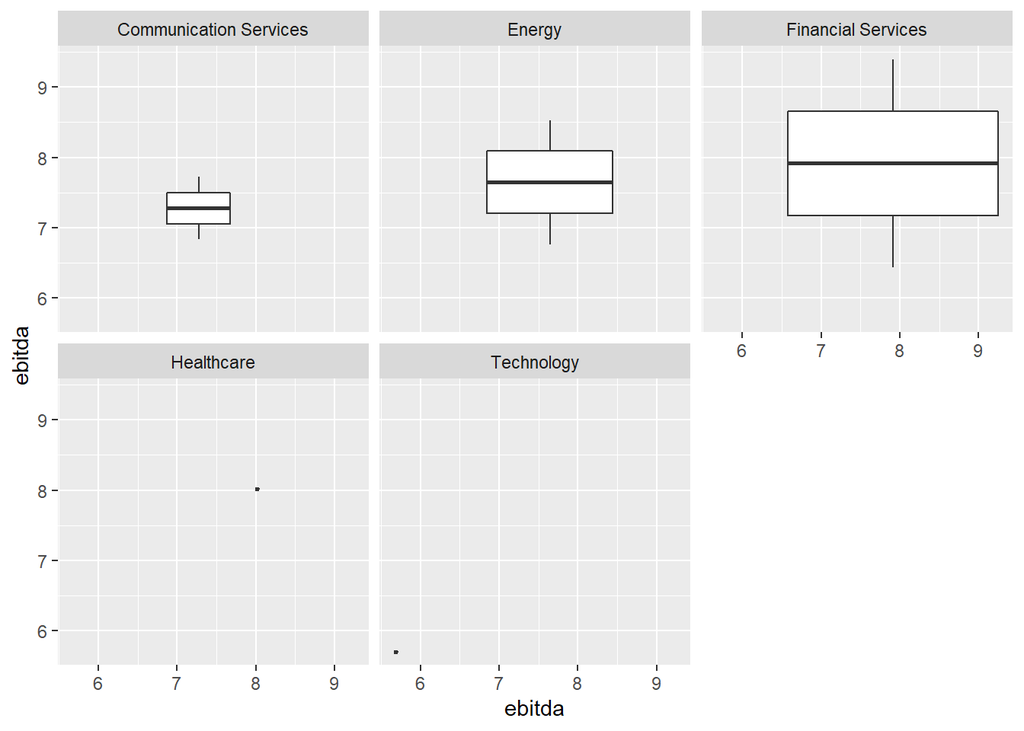

```r
stocks %>%
  dplyr::filter(ebitda<10) %>%
  ggplot(aes(ebitda, ebitda)) +
  geom_boxplot() +
  facet_wrap(~Industry)
```

## Value Analysis

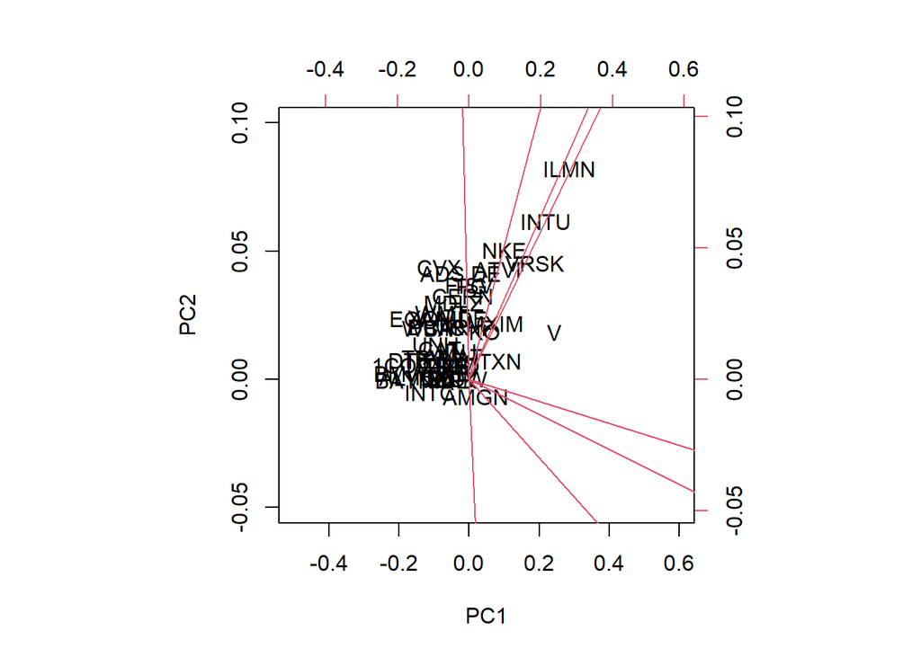

```r
issuer<-stocks%>%
  select(Symbol,intra_day,ent_value,trail_pe,for_pe,peg,ttm,mrq,rev,ebitda)

pca_value<-issuer%>%
  select(intra_day,ent_value,trail_pe,for_pe,peg,ttm,mrq,rev,ebitda)%>%
  prcomp(scale.=TRUE)
rownames(pca_value$x)<-pull(issuer,Symbol)
biplot(pca_value, expand=10,xlim=c(-0.5,0.6),ylim=c(-0.05,0.1))
```

```r
stocks %>% filter(Industry == "Technology")
```

```
##                                           Name Symbol Market
## 1                              CDW Corporation    CDW    NDX
## 2            Microchip Technology Incorporated   MCHP    NDX
## 3                                  Intuit Inc.   INTU    NDX
## 4                                 Fiserv, Inc.   FISV    NDX
## 5              Maxim Integrated Products, Inc.   MXIM    NDX
## 6               Texas Instruments Incorporated    TXN    NDX
## 7                      Applied Materials, Inc.   AMAT    NDX
## 8                        Microsoft Corporation   MSFT    DJI
## 9                            Intel Corporation   INTC    DJI
## 10                         Cisco Systems, Inc.   CSCO    DJI
## 11                                  Apple Inc.   AAPL    DJI
## 12 International Business Machines Corporation    IBM    DJI
##                                 Sector   Industry  intra_day  ent_value
## 1      Information Technology Services Technology      16.46      20.19
```

[output cut: 37 more lines]

## Risk

```r
stocks %>% select(Total.ESG.risk.score, Environmental.Risk.Score, Social.Risk.Score, Governance.Risk.Score)
```

```
##     Total.ESG.risk.score Environmental.Risk.Score Social.Risk.Score
## 1                     11                        4                 3
## 3                     21                        0                15
## 4                     34                       16                 9
## 6                     18                        1                11
## 7                     17                        0                10
## 8                     11                        1                 4
## 10                    31                        3                17
## 12                    19                        0                12
## 15                    20                        0                14
## 16                    20                        4                10
## 17                    24                        9                 7
## 19                    17                        6                 5
## 21                    35                        8                17
## 23                    26                       10                11
```

[output cut: 77 more lines]

```r
d <- apply(cbind(stocks$Environmental.Risk.Score, stocks$Social.Risk.Score, stocks$Governance.Risk.Score), 1, sum)
```

```r
all(stocks$Total.ESG.risk.score == d)
```

```
## [1] FALSE
```

```r
# checking if total esg risk score = environmrnt + social + government
stocks_tesg <- stocks[stocks[,15] == d,]
d <- apply(cbind(stocks_tesg$Environmental.Risk.Score, stocks_tesg$Social.Risk.Score, stocks_tesg$Governance.Risk.Score), 1, sum)
all(stocks_tesg$Total.ESG.risk.score == d, na.rm = TRUE)
```

```
## [1] TRUE
```

```r
stocks_risk <- stocks_tesg %>% select(Symbol, Environmental.Risk.Score, Social.Risk.Score, Governance.Risk.Score)
stocks_risk <- na.omit(stocks_risk)
```

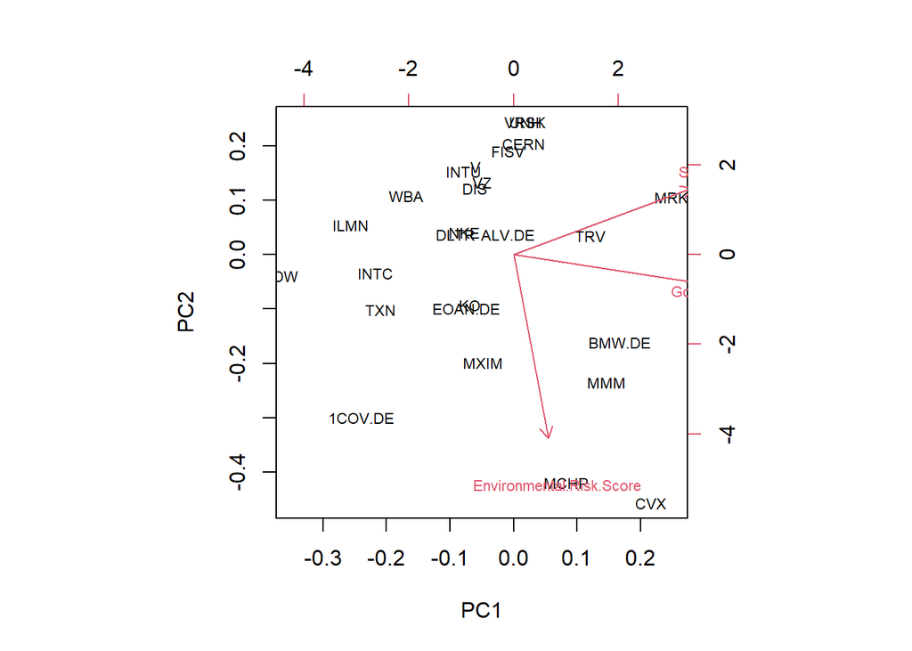

```r
pca_risk <- stocks_risk %>% select_if(is.numeric) %>% prcomp(scale. = TRUE)
rownames(pca_risk$x) <- pull(stocks_risk, Symbol)
biplot(pca_risk, xlim=c(-0.35,0.25), cex=0.7)
```